# Longitudinal data exploratory analysis

Antonia Chroni achroni@stjude.org for St. Jude Children’s Research Hospital BioHackathon Team 1

[figure not shown]

**Project: Comprehensive Omics Catalogue for Hartwell**

**St. Jude Children’s Research Hospital BioHackathon Team 1**

> Date started: 09/04/2024  
> Date completed: 9/06/2024  
> Report generated: 18:28:28 CDT 09/11/2024

# 1 Information about this notebook

This is an exploratory analysis of the data availability in terms of assays in the Comprehensive Omics Catalogue for Hartwell. This is critical for mitigating duplicate sequencing requests and efforts through Hartwell. This notebook aims to showcase: (1) which samples have already been sequenced by Hartwell, and (2) what omics data are available per sample.

For demo purposes, we use dummy data cohort and subset by human brain tumor samples. Finally, we investigate the number of samples per `cancer_type_brain`, `Assay` and `longitudinal`.

# 2 Set up

```r
suppressPackageStartupMessages({
  library(tidyverse)
})
```

# 3 Directories and paths to file Inputs/Outputs

```r
attach(params)
```

```r
analysis_dir <- file.path(root_dir, "analyses", "data-exploratory-analysis")
input_dir <- file.path(analysis_dir, "input")

# We will first read in metadata file as we need to define sample_name
metadata_file <- file.path(input_dir, input_file) # metadata input file
palette_file <- file.path(root_dir, "figures", "palettes", "assay_color_palette.tsv")
tumor_palette_file <- file.path(root_dir, "figures", "palettes", "tumor_color_palette.tsv")
longitudinal_palette_file <- file.path(root_dir, "figures", "palettes", "longitudinal_color_palette.tsv")

# File path to `plots` directory
plots_dir <- file.path(analysis_dir, "plots")

figures_plots_dir <- file.path(plots_dir, "figures-longitudinal")
if (!dir.exists(figures_plots_dir)) {
  dir.create(figures_plots_dir)}

source(paste0(analysis_dir, "/util/function-create-barplot.R"))
source(paste0(root_dir, "/figures/scripts/theme_plot.R"))
```

# 4 Read metadata file

We will subset by human brain tumor samples.

```r
# Read metadata
df <- read.csv(metadata_file, stringsAsFactors=FALSE)

# Number of samples per cancer_type_brain
assays_number <- length(df$SJUID)
samples_number <- length(unique(df$SJUID))
```

```r
cancer_type_brain_order <- cancer_type_order
longitudinal_order <- disease_stage_order

# Re-order df
f <- assay_order
df <- df %>%
  dplyr::mutate(Assay = factor(Assay),
                Assay = fct_relevel(Assay, f),
                longitudinal = factor(longitudinal),
                longitudinal = fct_relevel(longitudinal, longitudinal_order)) %>%
  arrange(cancer_type_brain, longitudinal, Assay)
```

## 4.1 Color palette for plotting

```r
# Read color palette
palette_df <- readr::read_tsv(palette_file, guess_max = 100000, show_col_types = FALSE)

# Define and order palette
palette <- palette_df$hex_codes
names(palette) <- palette_df$color_names

# Read color palette for tumor type
tumor_palette_df <- readr::read_tsv(tumor_palette_file, guess_max = 100000, show_col_types = FALSE)

# Define and order palette
tumor_palette <- tumor_palette_df$hex_codes
names(tumor_palette) <- tumor_palette_df$color_names


# Read color palette for longitudinal
longitudinal_palette_df <- readr::read_tsv(longitudinal_palette_file, guess_max = 100000, show_col_types = FALSE)

# Define and order palette
longitudinal_palette <- longitudinal_palette_df$hex_codes
names(longitudinal_palette) <- longitudinal_palette_df$color_names
```

# 5 Number of samples with assay information

Summary of samples per assay

| Assay | n |
| --- | --- |
| WES | 125 |
| WGBS | 70 |
| WGS | 126 |
| RNAseq | 156 |
| ATACseq | 70 |
| ChIPseq | 127 |
| Methylation | 203 |

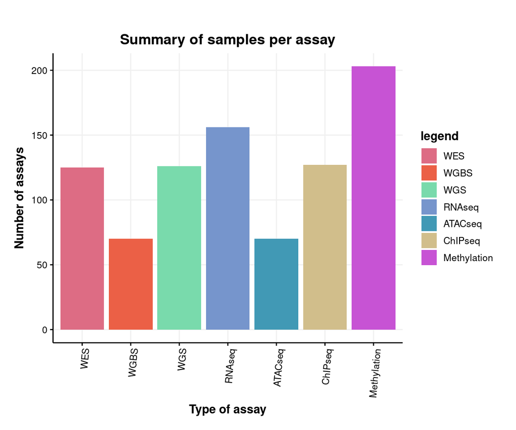

```r
# Define parameters for function
ylim <- max(tables1$n)

# Run function
fname <- paste0(figures_plots_dir, "/", "samples-per-assay.pdf")
p <- create_barplot(plot_df = tables1,
                    ylim = ylim,
                    x_value = tables1$Assay,
                    use_palette = palette,
                    xtitle ="Type of assay",
                    title_value = caption_value)
```

```r
pdf(file = fname, width = 6, height = 5)
print(p)
dev.off()
```

# 6 Number of samples per brain cancer type and assay

## 6.1 Overall assays

There are 59 brain tumor samples with 877 assays in total.

Summary of samples and assays per brain cancer type

| cancer_type_brain | n |
| --- | --- |
| Ependymoma | 400 |
| HGG | 93 |
| LGG | 346 |
| Medulloblastoma | 38 |

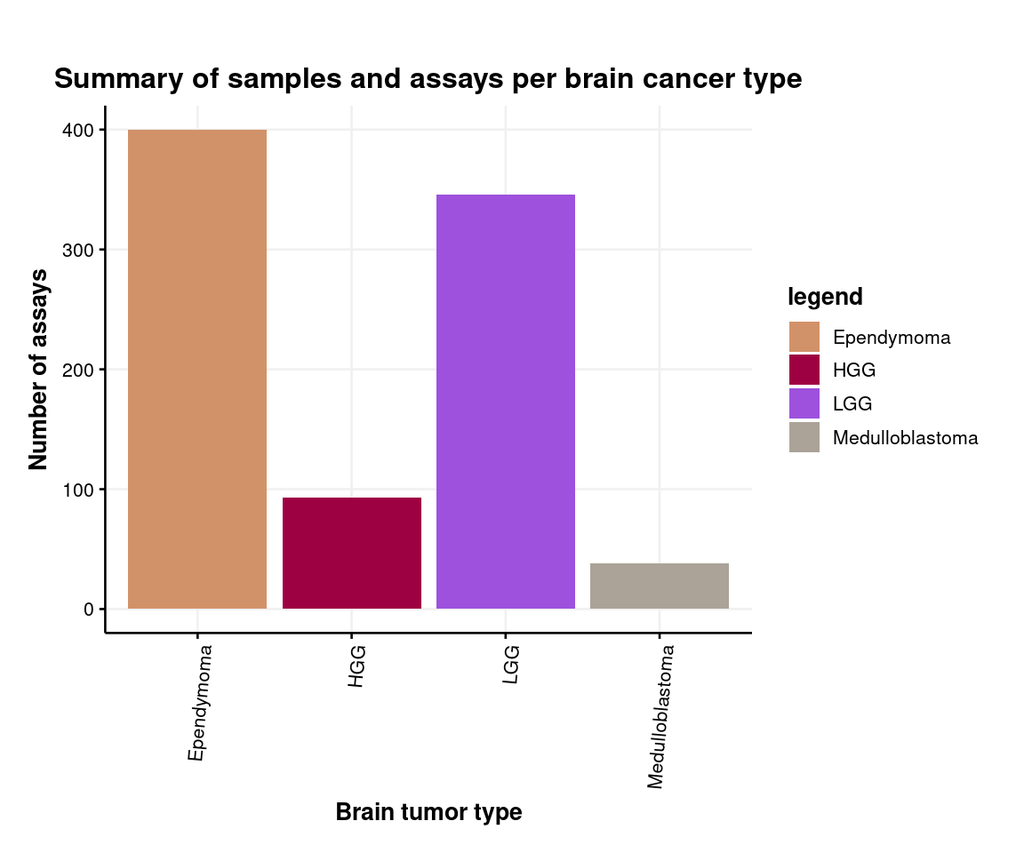

```r
# Define parameters for function
ylim <- max(tables1$n)

# Run function
fname <- paste0(figures_plots_dir, "/", "cancer-type-brain-assay-overall-longitudinal.pdf")
p <- create_barplot(plot_df = tables1,
                    ylim = ylim,
                    x_value = tables1$cancer_type_brain,
                    use_palette = tumor_palette,
                    xtitle ="Brain tumor type",
                    title_value = caption_value)
```

```r
pdf(file = fname, width = 6, height = 5)
print(p)
dev.off()
```

## 6.2 Per assay

Summary of samples and assays per brain cancer type and per assay

| cancer_type_brain | WES | WGBS | WGS | RNAseq | ChIPseq | Methylation | ATACseq |
| --- | --- | --- | --- | --- | --- | --- | --- |
| Ependymoma | 64 | 70 | 70 | 64 | 68 | 64 | 0 |
| HGG | 0 | 0 | 0 | 51 | 0 | 42 | 0 |
| LGG | 61 | 0 | 56 | 41 | 59 | 59 | 70 |
| Medulloblastoma | 0 | 0 | 0 | 0 | 0 | 38 | 0 |

```r
tables1 <- df %>% count(cancer_type_brain, Assay) %>%
  as.data.frame() %>%
  mutate_all(funs(replace_na(.,0)))
```

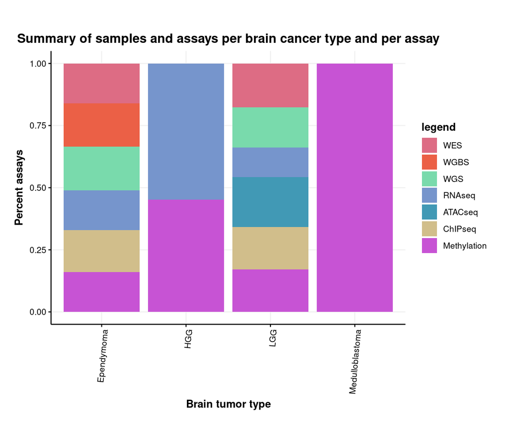

```r
# Plot stacked barplot
fname <- paste0(figures_plots_dir, "/", "cancer-type-brain-per-assay-longitudinal.pdf")
p <- create_stacked_barplot(plot_df = tables1,
                            x_value = tables1$cancer_type_brain,
                            use_palette = palette,
                            xtitle ="Brain tumor type",
                            legend = tables1$Assay,
                            title_value = caption_value)
```

```r
pdf(file = fname, width = 6, height = 5)
print(p)
dev.off()
```

## 6.3 Per disease stage

Summary of samples and assays per brain cancer type, per disease stage and per assay

| cancer_type_brain | longitudinal | WES | WGBS | WGS | RNAseq | ChIPseq | Methylation | ATACseq |
| --- | --- | --- | --- | --- | --- | --- | --- | --- |
| Ependymoma | Diagnosis | 15 | 15 | 15 | 15 | 15 | 13 | 0 |
| Ependymoma | Remission | 15 | 17 | 17 | 15 | 17 | 17 | 0 |
| Ependymoma | Relapse | 16 | 18 | 18 | 16 | 17 | 16 | 0 |
| Ependymoma | Deceased | 18 | 20 | 20 | 18 | 19 | 18 | 0 |
| HGG | Diagnosis | 0 | 0 | 0 | 13 | 0 | 11 | 0 |
| HGG | Remission | 0 | 0 | 0 | 13 | 0 | 11 | 0 |
| HGG | Relapse | 0 | 0 | 0 | 14 | 0 | 12 | 0 |
| HGG | Deceased | 0 | 0 | 0 | 11 | 0 | 8 | 0 |
| LGG | Diagnosis | 16 | 0 | 14 | 11 | 15 | 15 | 17 |
| LGG | Remission | 14 | 0 | 13 | 10 | 14 | 14 | 17 |
| LGG | Relapse | 17 | 0 | 15 | 11 | 16 | 16 | 19 |
| LGG | Deceased | 14 | 0 | 14 | 9 | 14 | 14 | 17 |
| Medulloblastoma | Diagnosis | 0 | 0 | 0 | 0 | 0 | 9 | 0 |
| Medulloblastoma | Remission | 0 | 0 | 0 | 0 | 0 | 10 | 0 |
| Medulloblastoma | Relapse | 0 | 0 | 0 | 0 | 0 | 10 | 0 |
| Medulloblastoma | Deceased | 0 | 0 | 0 | 0 | 0 | 9 | 0 |

# 7 Number of samples per brain cancer type, longitudinal, assay, and SJUID

Summary of cohort per brain cancer type, SJUID, disease stage, and assay

| cancer_type_brain | SJUID | longitudinal | WES | WGBS | WGS | ChIPseq | Methylation | RNAseq | ATACseq |
| --- | --- | --- | --- | --- | --- | --- | --- | --- | --- |
| Ependymoma | SJH0H5WYREP | Remission | 1 | 1 | 1 | 1 | 1 | 0 | 0 |
| Ependymoma | SJH0H5WYREP | Relapse | 1 | 1 | 1 | 1 | 1 | 0 | 0 |
| Ependymoma | SJH0H5WYREP | Deceased | 1 | 1 | 1 | 1 | 1 | 0 | 0 |
| Ependymoma | SJH2HPPEEKM | Diagnosis | 1 | 1 | 1 | 1 | 1 | 1 | 0 |
| Ependymoma | SJH2HPPEEKM | Remission | 1 | 1 | 1 | 1 | 1 | 1 | 0 |
| Ependymoma | SJH2HPPEEKM | Relapse | 1 | 1 | 1 | 1 | 1 | 1 | 0 |
| Ependymoma | SJH2HPPEEKM | Deceased | 1 | 1 | 1 | 1 | 1 | 1 | 0 |
| Ependymoma | SJH51B396IW | Diagnosis | 1 | 1 | 1 | 1 | 1 | 1 | 0 |
| Ependymoma | SJH51B396IW | Remission | 1 | 1 | 1 | 1 | 1 | 1 | 0 |
| Ependymoma | SJH51B396IW | Relapse | 1 | 1 | 1 | 1 | 1 | 1 | 0 |
| Ependymoma | SJH51B396IW | Deceased | 1 | 1 | 1 | 1 | 1 | 1 | 0 |
| Ependymoma | SJH5HCKPC97 | Remission | 0 | 1 | 1 | 1 | 1 | 1 | 0 |
| Ependymoma | SJH5HCKPC97 | Relapse | 0 | 1 | 1 | 1 | 1 | 1 | 0 |
| Ependymoma | SJH5HCKPC97 | Deceased | 0 | 1 | 1 | 1 | 1 | 1 | 0 |
| Ependymoma | SJH98QNKIUU | Remission | 0 | 1 | 1 | 1 | 1 | 1 | 0 |
| Ependymoma | SJH98QNKIUU | Relapse | 0 | 1 | 1 | 1 | 1 | 1 | 0 |
| Ependymoma | SJH98QNKIUU | Deceased | 0 | 1 | 1 | 1 | 1 | 1 | 0 |
| Ependymoma | SJH9YMLFOTI | Diagnosis | 1 | 1 | 1 | 1 | 1 | 1 | 0 |
| Ependymoma | SJH9YMLFOTI | Remission | 1 | 1 | 1 | 1 | 1 | 1 | 0 |
| Ependymoma | SJH9YMLFOTI | Relapse | 1 | 1 | 1 | 1 | 1 | 1 | 0 |
| Ependymoma | SJH9YMLFOTI | Deceased | 1 | 1 | 1 | 1 | 1 | 1 | 0 |
| Ependymoma | SJHA6KC56J6 | Diagnosis | 1 | 1 | 1 | 1 | 1 | 1 | 0 |
| Ependymoma | SJHA6KC56J6 | Remission | 1 | 1 | 1 | 1 | 1 | 1 | 0 |
| Ependymoma | SJHA6KC56J6 | Relapse | 1 | 1 | 1 | 1 | 1 | 1 | 0 |
| Ependymoma | SJHA6KC56J6 | Deceased | 1 | 1 | 1 | 1 | 1 | 1 | 0 |
| Ependymoma | SJHBKS7QSFO | Diagnosis | 1 | 1 | 1 | 1 | 1 | 1 | 0 |
| Ependymoma | SJHBKS7QSFO | Remission | 1 | 1 | 1 | 1 | 1 | 1 | 0 |
| Ependymoma | SJHBKS7QSFO | Relapse | 1 | 1 | 1 | 1 | 1 | 1 | 0 |
| Ependymoma | SJHBKS7QSFO | Deceased | 1 | 1 | 1 | 1 | 1 | 1 | 0 |
| Ependymoma | SJHC70DZRJS | Diagnosis | 1 | 1 | 1 | 1 | 1 | 1 | 0 |

[output cut: 206 more lines]

## 7.1 Plots

```r
tables1 <- df %>% count(cancer_type_brain, SJUID, longitudinal, Assay) %>%
  as.data.frame() %>%
  arrange(cancer_type_brain, longitudinal, Assay) %>%
  mutate(match_id_brain = paste(cancer_type_brain, SJUID, sep = "_"),
         match_id_brain_longitudinal = paste(cancer_type_brain, SJUID, longitudinal, sep = "_")) %>%
  mutate_all(funs(replace_na(.,0)))
```

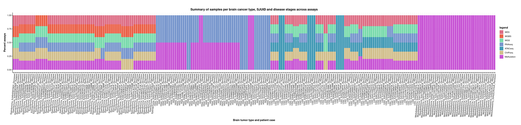

```r
# Run function
fname <- paste0(figures_plots_dir, "/", "cancer-type-brain-per-assay-patient.pdf")
p <- create_stacked_barplot(plot_df = tables1,
                            x_value = tables1$match_id_brain_longitudinal,
                            use_palette = palette,
                            xtitle ="Brain tumor type and patient case",
                            legend = tables1$Assay,
                            title_value = "Summary of samples per brain cancer type, SJUID and disease stages across assays")
```

```r
pdf(file = fname, width = 25, height = 6)
print(p)
dev.off()
```

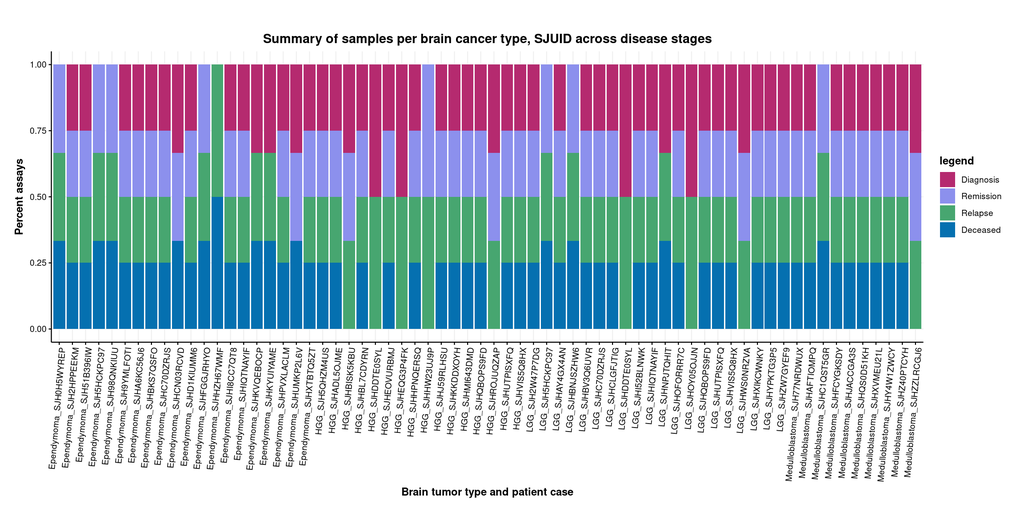

```r
# Run function
fname <- paste0(figures_plots_dir, "/", "cancer-type-brain-patient-longitudinal.pdf")
p <- create_stacked_barplot(plot_df = tables1,
                            x_value = tables1$match_id_brain,
                            use_palette = longitudinal_palette,
                            xtitle ="Brain tumor type and patient case",
                            legend = tables1$longitudinal,
                            title_value = "Summary of samples per brain cancer type, SJUID across disease stages")
```

```r
pdf(file = fname, width = 12, height = 6)
print(p)
dev.off()
```

# 8 Future directions

The current exploratory data analysis module can be expanded by investigating samples with paired assays. Moreover, if other metadata are available, e.g., disease_stage, treatment, this will build large, longitudinal cohorts with multi-omic sequencing data. Such an analysis permits consideration of samples according to the condition(s) of the experiment and research aims. In addition, it can be used to refine research questions and/or generate new ones.

This will facilitate collaboration across departments at St. Jude, expedite discoveries, and find cures for children with cancer and other catastrophic diseases.